# Méthodes biostatistiques

Modèles pour données corrélées

Les paramètres suivants doivent être définis dans R ou RStudio afin de reproduire les analyses présentées dans ce document. Les packages `ggplot2`, `ggfortify`, `hrbrthemes`, `directlabels`, `cowplot`, `texreg`, `lme4` et `geepack` ne font pas partie de la distribution R et doivent être installés si nécessaire :

```r
install.packages(c("ggplot2", "ggfortify", "hrbrthemes", "directlabels",
                     "cowplot", "texreg", "lme4", "geepack")
```

Les dépendances de ces packages seront installées automatiquement. On supposera également que les instructions R sont exécutées dans un répertoire de travail avec les fichiers de données accessibles dans un sous-répertoire `data/`. Si ce n’est pas le cas, il suffit de créer un sous-répertoire `data/` et d’y enregistrer les fichiers de données, ou de redéfinir les chemins d’accès dans les instructions de lecture des fichiers de données ci-après.

```r
library(ggplot2)
library(ggfortify)
library(hrbrthemes)
library(directlabels)
library(cowplot)
library(texreg)
library(Hmisc)
library(survival)
library(lme4)
library(geepack)
library(reshape2)
options(digits = 6, show.signif.stars = FALSE)
theme_set(theme_ipsum(base_size = 11))
```

# Modèles à effets aléatoires

## Chargement des données

Les données analysées ci-après proviennent d’un plan d’expérience dans lequel on s’intéresse à l’excès de graisses dans les selles causé par un déficit en enzymes digestives au niveau de l’intestin. Les mêmes sujets ont été soumis à différents traitements (suppléments en enzyme pancréatique). Il y a donc plusieurs observations par sujet. Les données sont disponibles au format RData dans le fichier `fat.rda` :

```r
load("data/fat.rda")
str(fat)
```

```
## 'data.frame':    24 obs. of  3 variables:
##  $ fecfat  : num  44.5 33 19.1 9.4 71.3 51.2 7.3 21 5 4.6 ...
##  $ pilltype: Factor w/ 4 levels "None","Tablet",..: 1 1 1 1 1 1 2 2 2 2 ...
##  $ subject : Factor w/ 6 levels "1","2","3","4",..: 1 2 3 4 5 6 1 2 3 4 ...
```

## Description des variables

Les moyennes et écarts-type pour chaque groupe de traitement sont reportées ci-dessous à l’aide de `Hmisc` :

```r
summary(fecfat ~ pilltype, data = fat, fun = smean.sd)
```

```
## fecfat     N= 24
##
## +--------+-------+--+-------+-------+
## |        |       |N |Mean   |SD     |
## +--------+-------+--+-------+-------+
## |pilltype|None   | 6|38.0833|22.4745|
## |        |Tablet | 6|16.5333|13.3209|
## |        |Capsule| 6|17.4167|12.9375|
## |        |Coated | 6|31.0667|24.2641|
## +--------+-------+--+-------+-------+
## |Overall |       |24|25.7750|20.0021|
## +--------+-------+--+-------+-------+
```

Une représentation graphique des données individuelles et moyennes est données ci-après.

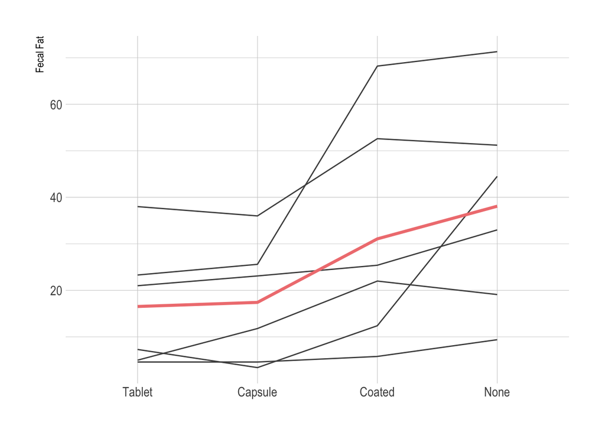

```r
d <- aggregate(fecfat ~ pilltype, data = fat, mean)
p <- ggplot(data = fat, aes(x = reorder(pilltype, fecfat), y = fecfat)) +
       geom_line(aes(group = subject), color = grey(.3)) +
       geom_line(data = d, aes(x = pilltype, y = fecfat, group = 1),
                 color = "lightcoral", size = 1.2) +
       labs(x = NULL, y = "Fecal Fat")
p
```

## Modélisation

Voici différents modèles permettant de décomposer la variance totale, dont un modèle d’ANOVA à mesures répétées (modèle `m3` ci-dessous) supposant la symétrie composée de la matrice de variance-covariance :

```r
m1 <- aov(fecfat ~ pilltype, data = fat)
m2 <- aov(fecfat ~ pilltype + subject, data = fat)
m3 <- aov(fecfat ~ pilltype + Error(subject), data = fat)
summary(m3)
```

```
##
## Error: subject
##           Df Sum Sq Mean Sq F value Pr(>F)
## Residuals  5   5588    1118
##
## Error: Within
##           Df Sum Sq Mean Sq F value Pr(>F)
## pilltype   3   2009     670    6.26 0.0057
## Residuals 15   1605     107
```

Et voici une approche par modèle de régression à effets aléatoires, ici un intercept aléatoire pour chaque sujet :

```r
m <- lmer(fecfat ~ pilltype + (1 | subject), data = fat)
summary(m)
```

```
## Linear mixed model fit by REML ['lmerMod']
## Formula: fecfat ~ pilltype + (1 | subject)
##    Data: fat
##
## REML criterion at convergence: 169.1
##
## Scaled residuals:
##     Min      1Q  Median      3Q     Max
## -1.2101 -0.6151 -0.0027  0.4571  1.7256
##
## Random effects:
##  Groups   Name        Variance Std.Dev.
##  subject  (Intercept) 253      15.9
##  Residual             107      10.3
## Number of obs: 24, groups:  subject, 6
##
## Fixed effects:
##                 Estimate Std. Error t value
## (Intercept)        38.08       7.74    4.92
## pilltypeTablet    -21.55       5.97   -3.61
## pilltypeCapsule   -20.67       5.97   -3.46
## pilltypeCoated     -7.02       5.97   -1.17
##
## Correlation of Fixed Effects:
##             (Intr) plltyT plltypCp
## pilltypTblt -0.386
## pilltypCpsl -0.386  0.500
## pilltypeCtd -0.386  0.500  0.500
```

```r
confint(m)
```

```
## Computing profile confidence intervals ...
```

```
##                     2.5 %   97.5 %
## .sig01            8.10894  30.2338
## .sigma            7.03296  13.6222
## (Intercept)      22.52784  53.6388
## pilltypeTablet  -32.83157 -10.2684
## pilltypeCapsule -31.94823  -9.3851
## pilltypeCoated  -18.29823   4.2649
```

Visuellement, le modèle à intercept aléatoire se traduit par des profils individuels en tous points identiques à l’exception du niveau moyen qui varie d’un individu à l’autre :

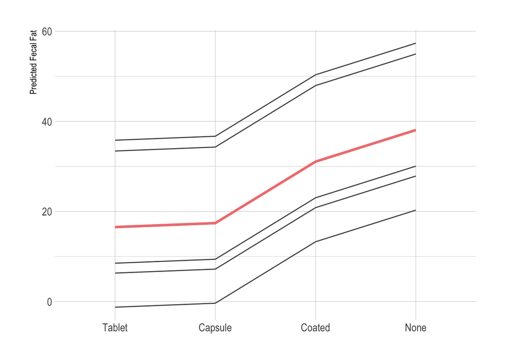

```r
yhat <- predict(m)
p <- ggplot(data = fat, aes(x = reorder(pilltype, fecfat), y = yhat)) +
       geom_line(aes(group = subject), color = grey(.3)) +
       geom_line(data = d, aes(x = pilltype, y = fecfat, group = 1),
                 color = "lightcoral", size = 1.2) +
       labs(x = NULL, y = "Predicted Fecal Fat")
p
```

# Cas des données longitudinales

## Chargement des données

Les données pour cette illustration portent sur un essai clinique randomisé comprenant deux bras de traitement et visant à étudier l’effet de l’administration d’ibuprofène par voie intraveineuse sur la mortalité de patients en état septique sévère. Les données sont disponibles dans le fichier Stata `sepsis` :

```r
sepsis <- foreign::read.dta("data/sepsis.dta")
str(sepsis)
```

```
## 'data.frame':    455 obs. of  23 variables:
##  $ id      : num  1 2 3 4 5 6 7 8 9 10 ...
##  $ treat   : Factor w/ 2 levels "Placebo","Ibuprofen": 1 2 1 2 1 2 2 1 2 1 ...
##  $ race    : Factor w/ 3 levels "White","Black",..: 1 2 2 1 1 1 1 1 1 1 ...
##  $ apache  : num  27 14 33 3 5 13 34 11 25 20 ...
##  $ o2del   : num  539 NA 551 1376 NA ...
##  $ fate    : Factor w/ 2 levels "Alive","Dead": 2 1 2 1 1 1 2 1 1 1 ...
##  $ followup: num  50 720 33 720 720 720 45 720 720 720 ...
##  $ temp0   : num  95.4 101.6 101 101 101.4 ...
##  $ temp1   : num  93.9 99 98.9 100.2 101.4 ...
##  $ temp2   : num  93.6 99.8 97.2 100 101.8 ...
##  $ temp3   : num  93 99.8 NA 99.5 101.4 ...
##  $ temp4   : num  90.3 99.6 NA 99.7 101.4 ...
##  $ temp5   : num  93.2 100.2 94.8 99.1 101 ...
##  $ temp6   : num  95 100.2 95.5 99.3 102.6 ...
##  $ temp7   : num  96.2 99 NA 99.6 100.8 ...
##  $ temp8   : num  98.8 99.9 97.2 98 100.6 ...
##  $ temp9   : num  97.5 99.8 99.2 97.8 99.8 ...
##  $ temp10  : num  97.8 99.6 NA 97.6 99.6 ...
##  $ temp11  : num  99.1 99.4 NA 98.4 99.6 ...
##  $ temp12  : num  95.6 101.2 NA 98 99.8 ...
##  $ temp13  : num  NA 101 NA 98.4 100.8 ...
##  $ temp14  : num  NA NA NA NA NA NA NA NA NA NA ...
##  $ temp15  : num  NA 100.6 NA 98.8 100 ...
##  - attr(*, "datalabel")= chr ""
##  - attr(*, "time.stamp")= chr " 2 Sep 2008 10:17"
##  - attr(*, "formats")= chr  "%9.0g" "%9.0g" "%9.0g" "%9.0g" ...
##  - attr(*, "types")= int  254 254 254 254 254 254 254 254 254 254 ...
##  - attr(*, "val.labels")= chr  "" "treatmnt" "race" "" ...
##  - attr(*, "var.labels")= chr  "Patient ID" "Treatment" "Race" "Baseline APACHE Score" ...
##  - attr(*, "version")= int 12
##  - attr(*, "label.table")=List of 3
##   ..$ treatmnt: Named int  0 1
##   .. ..- attr(*, "names")= chr  "Placebo" "Ibuprofen"
##   ..$ fate    : Named int  0 1
##   .. ..- attr(*, "names")= chr  "Alive" "Dead"
##   ..$ race    : Named int  0 1 2
##   .. ..- attr(*, "names")= chr  "White" "Black" "Other"
```

Voici quelques pré-traitements utiles :

```r
sepsis$treat <- as.factor(sepsis$treat)
sepsis$id <- factor(sepsis$id)
sepsis.long <- melt(sepsis, measure.vars = 8:14, id.vars = 1:2)
celsius2fahr <- function(x) (x-32) / 1.8              ## °F -> °C
sepsis.long$value <- celsius2fahr(sepsis.long$value)
```

## Description des variables

On ne s’intéresse qu’aux variables `treat` (groupe de traitement), `race` (ethnicité), `fate` (statut vital) et les différentes mesures de température (`temp*`). Il est possible d’aborder ce jeu de données sous un angle d’analyse de survie, mais on va principalement regarder l’évolution de la température après la prise en charge entre les deux groupes de patients. Voici quelques statistiques descriptives obtenues avec le package `Hmisc` :

```r
s <- summary(treat ~ fate + race + apache + temp0 + temp1, data = sepsis,
             method = "reverse", overall = TRUE)
print(s, digits = 3)
```

```
##
##
## Descriptive Statistics by treat
##
## +------------+---+-----------------+-----------------+-----------------+
## |            |N  |Placebo          |Ibuprofen        |Combined         |
## |            |   |(N=231)          |(N=224)          |(N=455)          |
## +------------+---+-----------------+-----------------+-----------------+
## |fate : Dead |455|    40%  ( 92)   |    38%  ( 84)   |    39%  (176)   |
## +------------+---+-----------------+-----------------+-----------------+
## |race : White|455|    68%  (156)   |    61%  (137)   |    64%  (293)   |
## +------------+---+-----------------+-----------------+-----------------+
## |    Black   |   |    25%  ( 58)   |    32%  ( 72)   |    29%  (130)   |
## +------------+---+-----------------+-----------------+-----------------+
## |    Other   |   |     7%  ( 17)   |     7%  ( 15)   |     7%  ( 32)   |
## +------------+---+-----------------+-----------------+-----------------+
## |apache      |454|  10.0/14.5/19.0 |  10.0/14.0/21.0 |  10.0/14.0/20.0 |
## +------------+---+-----------------+-----------------+-----------------+
## |temp0       |455| 99.9/100.8/101.7| 99.3/100.6/101.5| 99.5/100.7/101.6|
## +------------+---+-----------------+-----------------+-----------------+
## |temp1       |420| 99.2/100.5/101.5| 98.6/ 99.5/100.5| 98.9/ 99.9/101.1|
## +------------+---+-----------------+-----------------+-----------------+
```

L’évolution de la température (en °C) mesurée toutes les deux heures est résumée dans les deux figures suivantes, sous forme de données individuelles et agrégées sous forme de moyennes par période pour chacun des groupes de traitement.

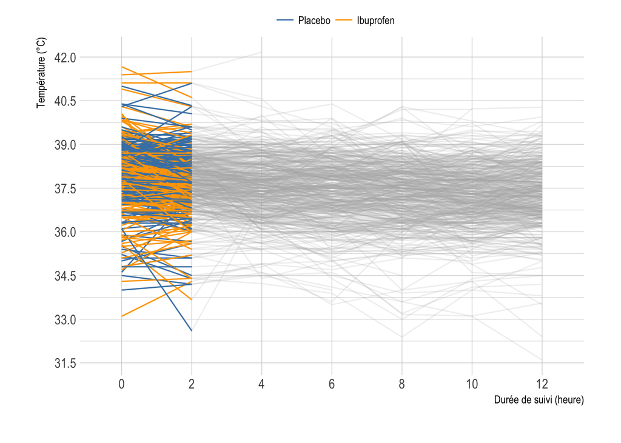

```r
p <- ggplot(data = na.omit(sepsis.long), aes(x = variable, y = value)) +
       geom_line(aes(group = id), col = grey(.7), alpha = .2) +
       geom_line(data = subset(na.omit(sepsis.long), variable %in% c("temp0", "temp1")),
                 aes(group = id, color = treat)) +
       scale_x_discrete(labels = seq(0, 6*2, by = 2)) +
       scale_y_continuous(breaks = seq(31.5, 43, by = 1.5)) +
       scale_color_manual("", values = c("steelblue", "orange")) +
       labs(x = "Durée de suivi (heure)", y = "Température (°C)") +
       theme(legend.position = c(.5, 1.05), legend.direction = "horizontal")
p
```

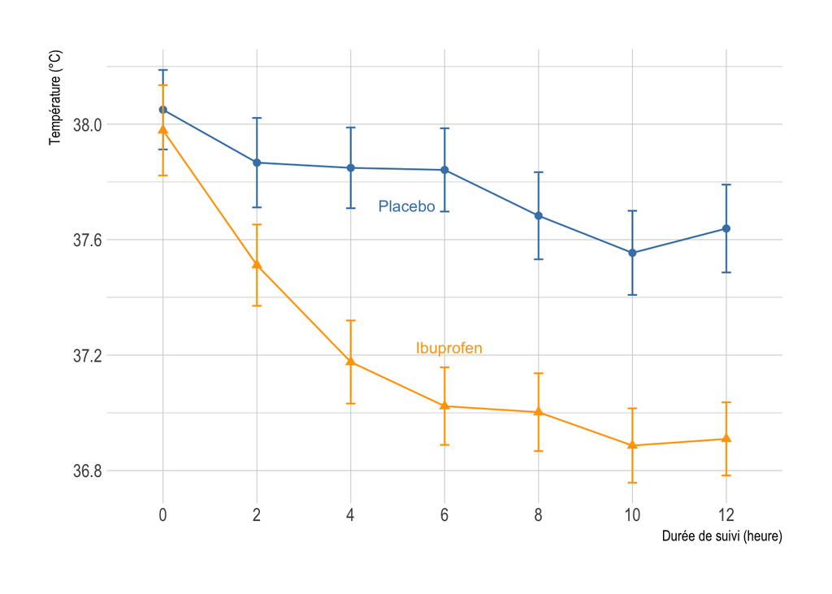

```r
d <- with(sepsis.long, summarize(value, llist(treat, variable), smean.cl.normal))

p <- ggplot(data = d, aes(x = variable, y = value, shape = treat, color = treat)) +
       geom_point(size = 2) +
       geom_line(aes(group = treat)) +
       geom_errorbar(aes(ymin=Lower, ymax=Upper), width=.1) +
       scale_color_manual("", values = c("steelblue", "orange")) +
       scale_x_discrete(labels = seq(0, 6*2, by = 2)) +
       guides(color = FALSE, shape = FALSE) +
       geom_dl(aes(label = treat), method = list("smart.grid", cex = .8)) +
       labs(x = "Durée de suivi (heure)", y = "Température (°C)")
p
```

Enfin, on peut représenter la probabilité de survie au cours du temps à l’aide d’une courbe de Kaplan-Meier : en l’absence de censure, celle-ci représente directement la proportion de décès.

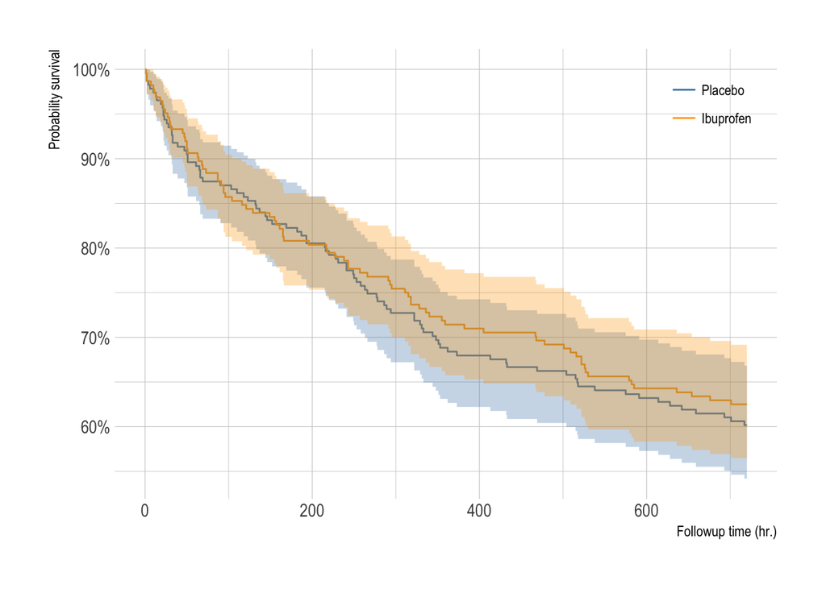

```r
## 0 = alive, 1 = dead
st <- with(sepsis, Surv(time = followup, event = as.numeric(fate)-1))
s <- survfit(st ~ treat, data = sepsis)
p <- autoplot(s, censor = FALSE) +
       scale_color_manual("", values = c("steelblue", "orange")) +
       scale_fill_manual("", values = c("steelblue", "orange")) +
       guides(fill = FALSE) +
       theme(legend.position = c(.9, .9)) +
       labs(x = "Followup time (hr.)", y = "Probability survival")
p
```

## Approche par modèle mixte

```r
cc <- aggregate(value ~ treat + id, sepsis.long, length)
idx <- cc$id[cc$value == 7]  ## complete case IDs
d <- subset(sepsis.long, id %in% idx)
d$id <- droplevels(d$id)     ## n = 328
names(d)[3] <- "time"
levels(d$time) <- 0:6
d$time <- as.numeric(as.character(d$time))
```

```r
## lme(value ~ time * treat, data = d, random = ~ 1 | id)
m1 <- lmer(value ~ time * treat + (1 | id), data = d)
summary(m1)
```

```
## Linear mixed model fit by REML ['lmerMod']
## Formula: value ~ time * treat + (1 | id)
##    Data: d
##
## REML criterion at convergence: 5030
##
## Scaled residuals:
##    Min     1Q Median     3Q    Max
## -4.506 -0.508 -0.028  0.487  4.876
##
## Random effects:
##  Groups   Name        Variance Std.Dev.
##  id       (Intercept) 0.734    0.857
##  Residual             0.351    0.592
## Number of obs: 2296, groups:  id, 328
##
## Fixed effects:
##                     Estimate Std. Error t value
## (Intercept)         37.99699    0.07264     523
## time                -0.07178    0.00858      -8
## treatIbuprofen      -0.23434    0.10467      -2
## time:treatIbuprofen -0.09926    0.01237      -8
##
## Correlation of Fixed Effects:
##             (Intr) time   trtIbp
## time        -0.354
## treatIbprfn -0.694  0.246
## tm:trtIbprf  0.246 -0.694 -0.354
```

Le second modèle inclut une pente aléatoire pour chaque patient, en plus de l’intercept aléatoire :

```r
## lme(value ~ time * treat, data = d, random = ~ time | id)
m2 <- lmer(value ~ time * treat + (time | id), data = d)
```

Les troisième et quatrième modèles incluent, respectivement, les deux mêmes effets aléatoires, mais cette fois sans corrélation, et seulement une pente aléatoire entre les deux groupes :

```r
## lme(value ~ time * treat, data = d, random = list(id = pdDiag(~ time)))
m3 <- lmer(value ~ time * treat + (1 | id) + (0 + time | id), data = d)

## lme(value ~ time * treat, data = d, random = ~ 0 + time | id)
m4 <- lmer(value ~ time * treat + (0 + time | id), data = d)
```

```r
screenreg(list(m1, m2, m3), include.variance = TRUE)
```

```
##
## ==================================================================
##                           Model 1       Model 2       Model 3
## ------------------------------------------------------------------
## (Intercept)                  38.00 ***     38.00 ***     38.00 ***
##                              (0.07)        (0.08)        (0.08)
## time                         -0.07 ***     -0.07 ***     -0.07 ***
##                              (0.01)        (0.01)        (0.01)
## treatIbuprofen               -0.23 *       -0.23 *       -0.23 *
##                              (0.10)        (0.12)        (0.11)
## time:treatIbuprofen          -0.10 ***     -0.10 ***     -0.10 ***
##                              (0.01)        (0.02)        (0.02)
## ------------------------------------------------------------------
## AIC                        5042.04       4699.52       4767.09
## BIC                        5076.47       4745.43       4807.26
## Log Likelihood            -2515.02      -2341.76      -2376.54
## Num. obs.                  2296          2296          2296
## Num. groups: id             328           328           328
## Var: id (Intercept)           0.73          1.01          0.87
## Var: Residual                 0.35          0.23          0.24
## Var: id time                                0.03
## Cov: id (Intercept) time                   -0.08
## Var: id.1 time                                            0.02
## ==================================================================
## *** p < 0.001, ** p < 0.01, * p < 0.05
```

```r
anova(m1, m3, m2)
```

```
## refitting model(s) with ML (instead of REML)
```

```
## Data: d
## Models:
## m1: value ~ time * treat + (1 | id)
## m3: value ~ time * treat + (1 | id) + (0 + time | id)
## m2: value ~ time * treat + (time | id)
##    Df  AIC  BIC logLik deviance  Chisq Chi Df Pr(>Chisq)
## m1  6 5020 5054  -2504     5008
## m3  7 4747 4787  -2366     4733 274.85      1     <2e-16
## m2  8 4679 4725  -2332     4663  69.71      1     <2e-16
```

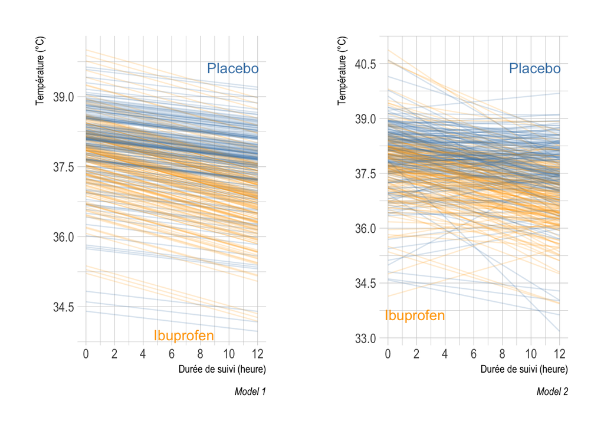

## Approche par équations généralisées

Contrairement aux approches conditionnelles présentées plus haut, les équations généralisées permettent d’estimer l’évolution moyenne (et la structure de covariance) d’un ensemble d’observations corrélées. Les packages `gee` et `geepack` peuvent être utilisés, sachant que le package `gee` repose sur des erreurs-type asymptotiques. Les illustrations qui suivent reposent sur `geepack`.

Voici un modèle équivalent, sur le principe, au modèle à effets aléatoires précédents où l’on modélise l’évolution moyenne de la température en fonction du temps en interaction avec le groupe de traitement et en supposant une matrice de variance-covariance de travail dite “exchangeable” :

```r
m <- geeglm(value ~ time * treat, data = d, id = id, corstr = "exch", scale.fix=TRUE)
summary(m)
```

```
##
## Call:
## geeglm(formula = value ~ time * treat, data = d, id = id, corstr = "exch",
##     scale.fix = TRUE)
##
##  Coefficients:
##                     Estimate Std.err     Wald Pr(>|W|)
## (Intercept)          37.9970  0.0544 4.88e+05  < 2e-16
## time                 -0.0718  0.0153 2.21e+01  2.5e-06
## treatIbuprofen       -0.2343  0.0810 8.37e+00   0.0038
## time:treatIbuprofen  -0.0993  0.0221 2.01e+01  7.2e-06
##
## Scale is fixed.
##
## Correlation: Structure = exchangeable  Link = identity
##
## Estimated Correlation Parameters:
##       Estimate Std.err
## alpha        0       0
## Number of clusters:   2296   Maximum cluster size: 1
```

Pour obtenir les matrices de variance-covariance estimée et de travail, il est nécessaire d’estimer les paramètres du modèle avec la fonction `geese` au lieu de `geeglm` :

```r
m0 <- geese(value ~ time * treat, data = d, id = id, corstr = "exch", scale.fix=TRUE)
m0$vbeta
```

```
##           [,1]      [,2]      [,3]      [,4]
## [1,]  0.002959 -0.000685 -0.002959  0.000685
## [2,] -0.000685  0.000233  0.000685 -0.000233
## [3,] -0.002959  0.000685  0.006560 -0.001514
## [4,]  0.000685 -0.000233 -0.001514  0.000489
```

```r
m0$vbeta.naiv
```

```
##           [,1]      [,2]      [,3]      [,4]
## [1,]  0.002949 -0.000681 -0.002949  0.000681
## [2,] -0.000681  0.000227  0.000681 -0.000227
## [3,] -0.002949  0.000681  0.006122 -0.001413
## [4,]  0.000681 -0.000227 -0.001413  0.000471
```

Enfin, voici les prédictions que donne cette approche marginale :

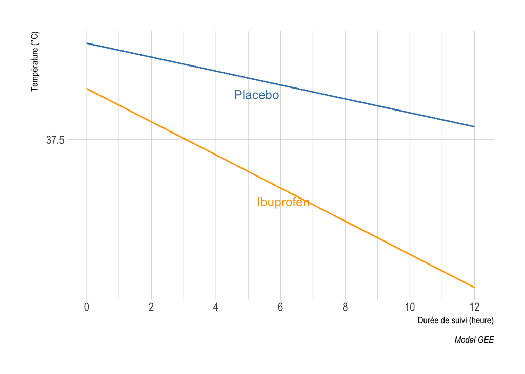

```r
d$yhat3 <- predict(m)
p <- ggplot(data = d, aes(x = time, y = yhat3, color = treat)) +
       geom_line(aes(group = id), alpha = .2) +
       scale_x_continuous(breaks = 0:6, labels = seq(0, 6*2, by = 2)) +
       scale_y_continuous(breaks = seq(31.5, 43, by = 1.5)) +
       scale_color_manual("", values = c("steelblue", "orange")) +
       guides(color = FALSE) +
       geom_dl(aes(label = treat), method = "smart.grid") +
       labs(x = "Durée de suivi (heure)", y = "Température (°C)", caption = "Model GEE")
p
```

# Exercice d’application

A longitudinal study of the health effects of air pollution. (Ware et al., 1984; Fitzmaurice and Laird, 1993)

Table of counts of wheezing status (Yes/No) for N = 537 children aged 7 to 10 years, with following two factors: maternal smoking (smoke, considered fixed) and time (age).

What is the marginal expectation of children’s response as a function of these co- variates (including the interaction smoke:time)?

```r
data(ohio, package = "geepack")
str(ohio)
```

```
## 'data.frame':    2148 obs. of  4 variables:
##  $ resp : int  0 0 0 0 0 0 0 0 0 0 ...
##  $ id   : int  0 0 0 0 1 1 1 1 2 2 ...
##  $ age  : int  -2 -1 0 1 -2 -1 0 1 -2 -1 ...
##  $ smoke: int  0 0 0 0 0 0 0 0 0 0 ...
```

```r
ohio$age <- ohio$age + 9    ## in years
```

Le tableau suivant résume la proportion de cas en fonction de l’âge (lignes) et du statut fumeur (colonne) :

```r
summary(resp ~ age + smoke, data = ohio, method = "cross")
```

```
##
##  mean by age, smoke
##
## +----+
## |N   |
## |resp|
## +----+
## +---+-----+-----+-----+
## |age|  0  |  1  | ALL |
## +---+-----+-----+-----+
## |7  | 350 | 187 | 537 |
## |   |0.160|0.166|0.162|
## +---+-----+-----+-----+
## |8  | 350 | 187 | 537 |
## |   |0.149|0.209|0.169|
## +---+-----+-----+-----+
## |9  | 350 | 187 | 537 |
## |   |0.143|0.187|0.158|
## +---+-----+-----+-----+
## |10 | 350 | 187 | 537 |
## |   |0.106|0.139|0.117|
## +---+-----+-----+-----+
## |ALL|1400 | 748 |2148 |
## |   |0.139|0.175|0.152|
## +---+-----+-----+-----+
```

1. Estimer les paramètres d’un modèle GEE avec une matrice de variance-covariance non stucturée (`unstructured`) ou “exchangeable” et un terme d’interaction `age:smoke`. Attention, la variable étant binaire, il est nécessaire de préciser une famille de type `binomial`. Le statut fumeur de la mère est-il significatif au seuil conventionel de 5 % ? Même question pour l’âge.
2. Calculer l’odds-ratio ajusté pour la variable `age`, avec son son intervalle de confiance à 95 %.
3. Représenter graphiquement les prédictions moyennes de ce modèle.